# Jupyter

- Startup exercise
- Use in reproducible research
- History and JupyterLab
- Other uses
- Slideshows

## Startup exercise

Task:

- Start your own Jupyter server

On Windows, you can find a launcher for IPython Notebook under Anaconda in the Start menu. Alternatively you can open a command prompt, navigate to your folder and use the command bellow.

On Linux or OS X, you can start IPython Notebook from the command line. First open a terminal window, use 'cd' to navigate to the directory where you want to store your Python files and notebook document files. Then run this command:

```
jupyter notebook
```

You will see something like:

```
[NotebookApp] Serving notebooks from current/directory/pathway
```

Make sure the course material is in that directory.

Here is how to specify a different home directory:

```
jupyter notebook --notebook-dir=/path/to/course/dir
```

Keep in mind that on Windows the paths are specified in a different manner.

## Use in reproducible research

> Open source, interactive data science and scientific computing across over 40 programming languages. The Jupyter Notebook is a web application that allows you to create and share documents that contain live code, equations, visualizations and explanatory text. Uses include: data cleaning and transformation, numerical simulation, statistical modeling, machine learning and much more. Read more about [Jupyter](https://jupyter.org/).

We are concerned, among other things (it is to be hoped), with increasing the capability of our NBIS staff, collaborators, and wider public to reproduce/resell/recycle/hack our work. Like many others, I used Jupyter and similar platforms for several reasons:

- As a way to hand out research results to my collaborators and public.
- Keeping track of my work (internal notebooks).
- Organize course material.
- Cloud development on the go with Sage, Picloud, etc.
- Provide a fast OS independent web GUI toolkit.
- Use of a Star Trek bridge from which to run/edit scripts in multiple languages. If you are like me and worked with some fifty programming languages over a 27 years timeframe, having to constantly change editors and displays kind of sucks.
- Scallable computing (big data interface).

Other uses of Jupyter, that are common enough, but I was less concerned with before include:

- Documenting a program, pipeline or library.
- Colaborative work.
- Batch running, scheduling

We shall take those points one by one with some examples.

### JupyterLab

Read here about the future of the Jupyter Notebook: https://blog.jupyter.org/2016/07/14/jupyter-lab-alpha/. Some of my key remarks:

- Python and Julia remain central.
- Separate file browser, console and code editor added to the notebook server.
- The project moves out of Berkeley (partnership with Continuum Analytics, Tech at Bloomberg).

### History

I don't know the early beginnings, but I first saw notebooks that can compute in an Astronomy lab from the nineties, where they were using Mathematica notebooks for symbolic mathematics computations. Among mathematicians there is a tribe that became hateful of too much symbolic writing, and they were the first enthusiasts. Two major developments happened since: the ability to write code cells and the web.

Jupyter name is an agglutination of Julia, Python and R and is pronounced in reference to a pie rather than a planet. It originates at Berkeley (also home of Julia and Apache Spark) from a project that now is independent, called [IPython](https://ipython.org/). IPython is the best interactive shell for Python for scientific computing and now provides one of many kernels for running Python code in Jupyter.

Projects similar to Jupyter:

- [Mathematica](http://www.wolfram.com/cdf/?source=nav) has its own notebook. Somehow I could never afford it. Matlab, Octave, Sage and the like all integrate into Jupyter but often develop their own notebooks.
- R:
  - [R Markdown](http://rmarkdown.rstudio.com/) often used with report generation with [knitr](http://yihui.name/knitr/).
  - [Shiny](http://shiny.rstudio.com/) is often viewed as something similar. Purely web application frameworks for Python similar even moe similar to Shiny would include Flask and Django.
  - Other R possibilities range from to the "R only" Jupyter clone [RCloud](http://att.github.io/rcloud/) to web publishing with [RPubs](http://www.rpubs.com/). Taken together, they make up a decent Jupyter replacement. For R.
- The latest efforts come unsurprisingly from big data, such as [spark-notebook](http://spark-notebook.io/) and [Beaker](http://beakernotebook.com/).

### Can you cook eggs with Jupyter? Yes, you need a frying pan and an oven...

Don't expect Jupyter to always work. It is very dependent on your ability to have their latest update on the computer, wait for bugs to be solved, and circumvent problems. If you stay on the beaten track the user experience is fabulous, although limited.

Some known limitations:

- Support for Python is the best, anything else is less than optimal.
- Collaborative tools are new and not super fun.
- Jupyter provides a non-native aproach to parallel computing. Many parallel computing machines have their own platforms.
- You cannot open notebooks with a double click. This CAN be done, with average OS admin skill, it is just not how things work (yet?) by default. You have to open a web server first. This is not an acessible Office replacer.
- It won't replace Wiki. The wiki is much better at displaying collaborative content for the web. So our Confluence wiki pages are better left where they sit.
- For great looks, Javascript and web development is essential.

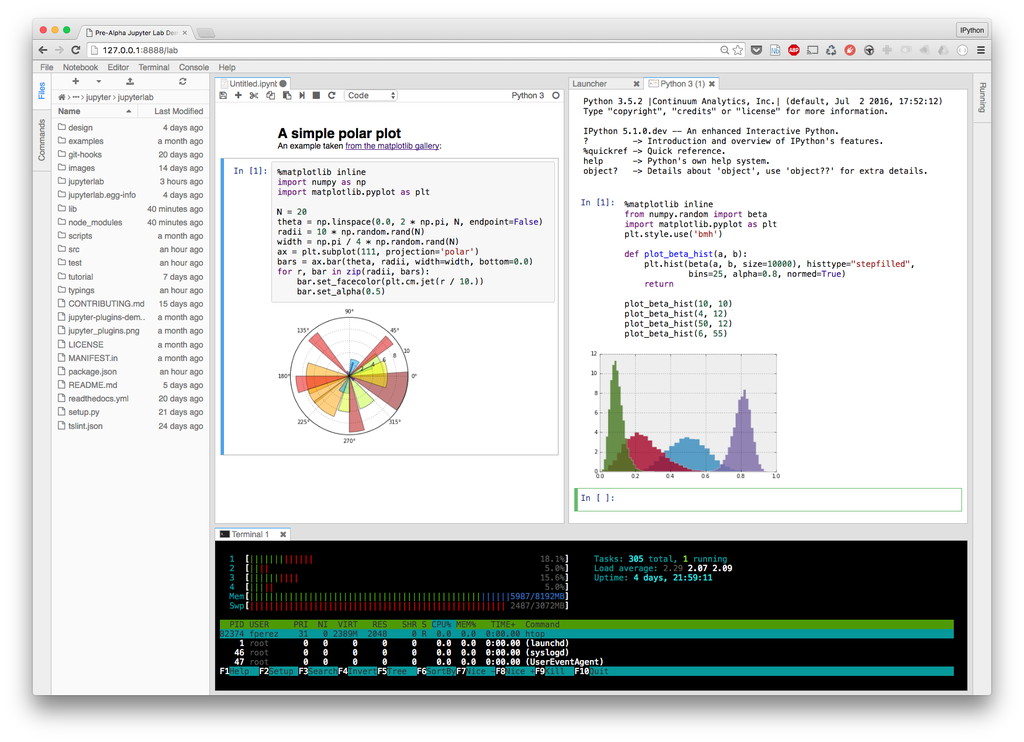

```python
# Something Lena asked
from IPython.display import Image
Image('https://blog.jupyter.org/content/images/2016/07/jlab-screenshot-nb-con-term-2.png')
```

### And now, the Hello World! Oh noo

To start using Jupyter please follow this [notebook](https://github.com/grokkaine/biopycourse/blob/master/day1/what.ipynb) that I use during my Python classes. Or help yourself with Dr Google. THE point about Jupyter is that you can do this thing (called a code cell):

```python
m = "Hello World!"
```

```python
def f(message):
    print(message)
```

[output not shown]

Each code cell will communicate with the others because underneath a notebook is the same shell/kernel/language (IPython/Python in this particular case, but you can just as well use [IRkernel](https://irkernel.github.io/)/R). If you created a notebook with a Kernel other than IPython you will have* to type the code in the appropriate languages. Some languages (kernels) however are very xenophoric, most notably Python and Julia, so you can call many other languages if you use them.

Note: *A different kernel can be set for a certain code cell.

```python
m = 8
```

```python
f(m)
```

```
8
```

The text cells are commonly typed in [Markdown](https://github.com/adam-p/markdown-here/wiki/Markdown-Cheatsheet). They can also include html and latex.

| Static |  |
| --- | --- |
| HTML | TABLE |

Static latex: $$c = \sqrt{a^2 + b^2}$$

Dynamic latex and html:

```python
%%latex
\begin{align}
\nabla \times \vec{\mathbf{B}} -\, \frac1c\, \frac{\partial\vec{\mathbf{E}}}{\partial t} & = \frac{4\pi}{c}\vec{\mathbf{j}} \\
\nabla \cdot \vec{\mathbf{E}} & = 4 \pi \rho \\
\nabla \times \vec{\mathbf{E}}\, +\, \frac1c\, \frac{\partial\vec{\mathbf{B}}}{\partial t} & = \vec{\mathbf{0}} \\
\nabla \cdot \vec{\mathbf{B}} & = 0
\end{align}
```

\begin{align} \nabla \times \vec{\mathbf{B}} -\, \frac1c\, \frac{\partial\vec{\mathbf{E}}}{\partial t} & = \frac{4\pi}{c}\vec{\mathbf{j}} \\ \nabla \cdot \vec{\mathbf{E}} & = 4 \pi \rho \\ \nabla \times \vec{\mathbf{E}}\, +\, \frac1c\, \frac{\partial\vec{\mathbf{B}}}{\partial t} & = \vec{\mathbf{0}} \\ \nabla \cdot \vec{\mathbf{B}} & = 0 \end{align}

```python
from IPython.core.display import HTML
HTML('<iframe src=http://nbis.se/?useformat=mobile width=700 height=350>')
```

[interactive chart not shown]